# Data Containers and Data Visualization

Niels Richard Hansen

This vignette demonstrates how to use the classes `ContinuousProcess`, `MarkedPointProcess` and `JumpProcess` as data containers and how to visualize the data they contain.

First we load the example data. The data sets are `contExam` of class `ContinuousProcess`, `pointExam` of class `MarkedPointProcess` and `jumpExam` of class `JumpProcess`.

```r
library(ppstat)
data(example)
```

Showing data structure.

```r
contExam
```

```
## Class: ContinuousProcess
## Dimensions: 4004 x 3
## Index variable: time
##
## 4 units.
##    id: A B C D
##
## 3 variables.
##    gender foo bar
```

Summarizing the data.

```r
summary(contExam)
```

```
## Class: ContinuousProcess
## Dimensions: 4004 x 3
## Index variable: time
##
## 4 units.
##    id: A B C D
##
## 3 variables.
##    gender foo bar
##
##   grid-points time-range gender median(foo) median(bar)
## A        1001     [0;10]      M  -7.4004049    46.72515
## B        1001     [0;10]      M   0.9732583    38.52012
## C        1001     [0;10]      M  18.1055244    14.29927
## D        1001     [0;10]      F   5.0987016    58.12943
```

Plotting data.

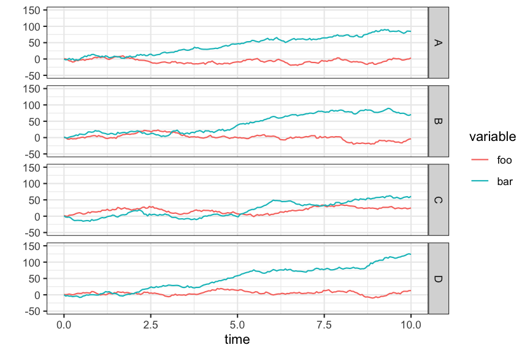

```r
plot(contExam)
```

Subsetting data.

```r
subset(contExam, id %in% c("C","D","F"))
```

```
## Class: ContinuousProcess
## Dimensions: 2002 x 3
## Index variable: time
##
## 2 units.
##    id: C D
##
## 3 variables.
##    gender foo bar
```

```r
subset(contExam, foo > 0)
```

```
## Class: ContinuousProcess
## Dimensions: 2611 x 3
## Index variable: time
##
## 4 units.
##    id: A B C D
##
## 3 variables.
##    gender foo bar
```

```r
subset(contExam, gender == "F")
```

[output not shown]

Plotting a subset.

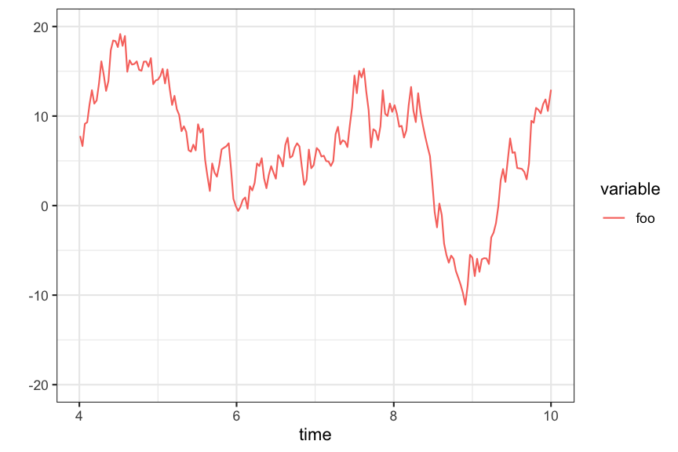

```r
plot(subset(contExam, subset = (time > 4 & gender == "F"), select = foo))
```

Modifying plot using ggplot2.

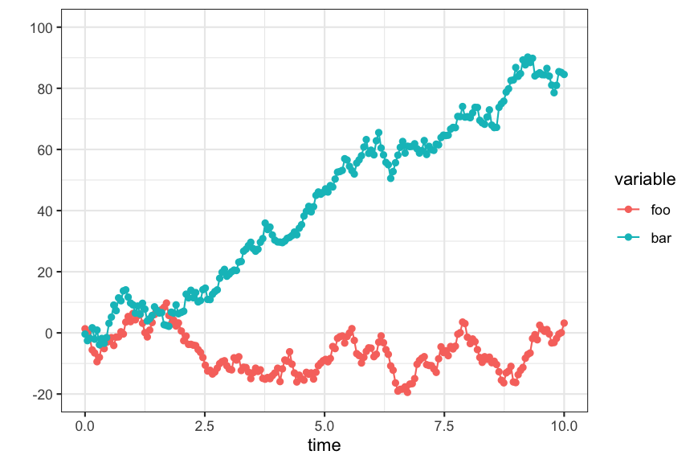

```r
plot(subset(contExam, id == "A")) + geom_point()
```

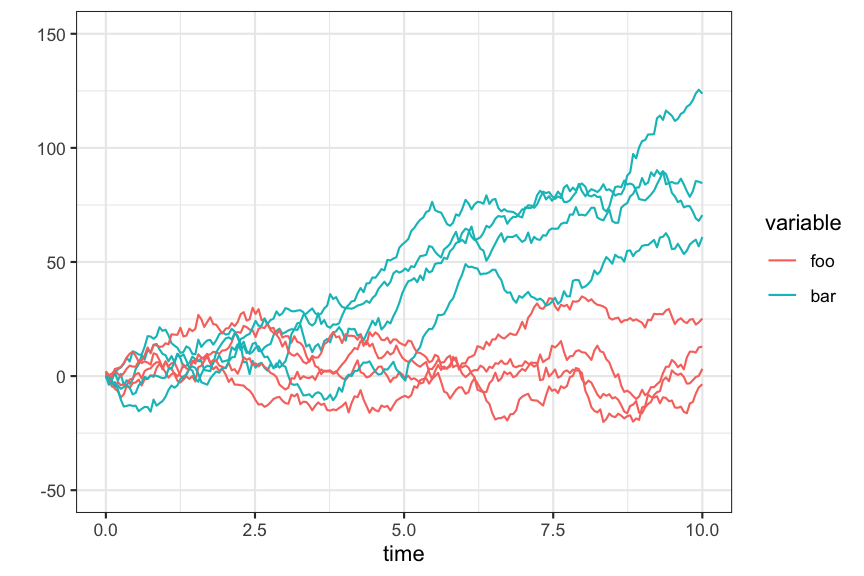

```r
plot(contExam) + facet_null()
```

More sophisticated plots can be produced, e.g. different uses of faceting and grouping.

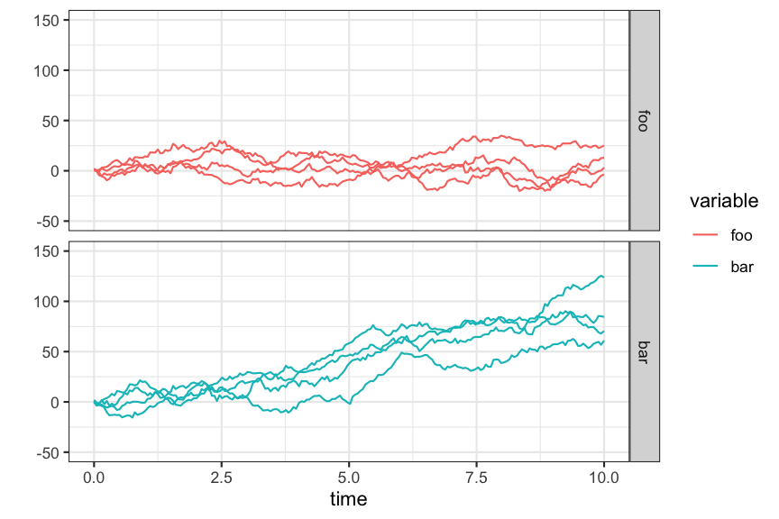

```r
plot(contExam) + facet_grid(variable ~ ., scale = "free_y")
```

To do this depending on unit-specific variables we must specify an additional argument to the plot such that these variables are included in the plot data.

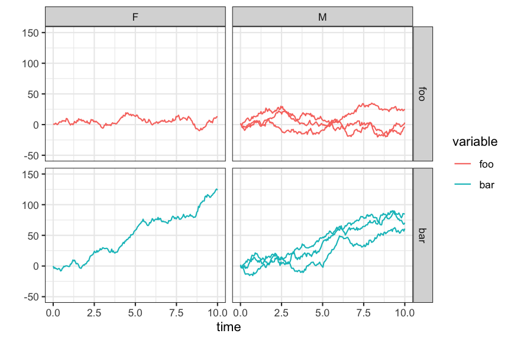

```r
plot(contExam, allUnitData = TRUE) +
  facet_grid(variable ~ gender, scale = "free_y")
```

Subsetting to non-contiguous subsets of the time axis is possible, but `plot` assumes a contiguous x-axis and interpolates the graph.

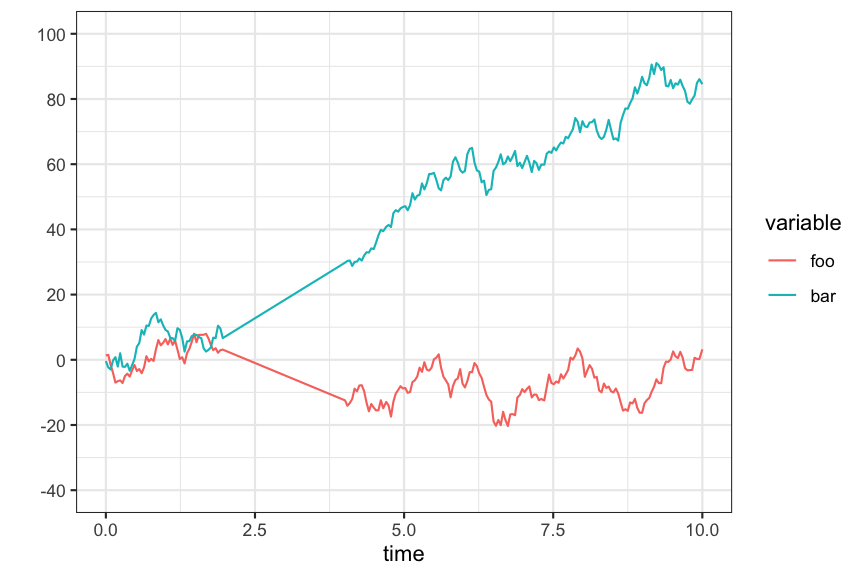

```r
plot(subset(contExam, id == "A" & (time < 2 | time > 4)))
```

Factor columns are plotting using a different aesthetic mapping.

```r
plot(factExam)
```

[output not shown]

The default is to drop one level (the first), but this can be changed or bypassed by setting the `dropLevels argument.

```r
plot(factExam, dropLevels = 2)
plot(factExam, dropLevels = NULL)
```

[output not shown]

Summarizing a MarkedPointProcess object gives additional informations on the number of points for each unit and each mark.

```r
summary(pointExam)
```

```
## Class: MarkedPointProcess
## Dimensions: 4046 x 5
## Index variable: time
##
## 4 units.
##    id: A B C D
##
## 5 variables.
##    gender foo bar ALPHA BETA
##
##   grid-points time-range gender median(foo) median(bar) #ALPHA #BETA
## A        1013     [0;10]      M  -7.3237089    46.62783      6     6
## B        1015     [0;10]      M   0.9347193    37.45946      8     6
## C        1007     [0;10]      M  18.1055244    14.32739      2     4
## D        1011     [0;10]      F   5.0997277    57.70206      3     7
```

A combined plot for unit “A”.

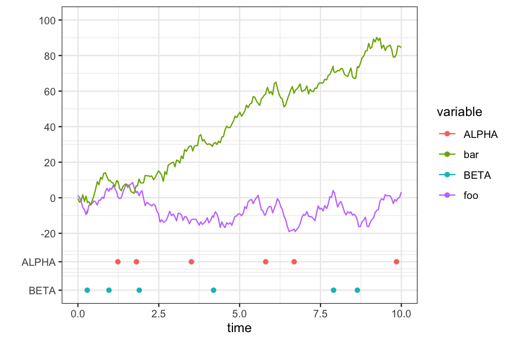

```r
plot(subset(pointExam, id =="A"))
```

Plotting the point process data only.

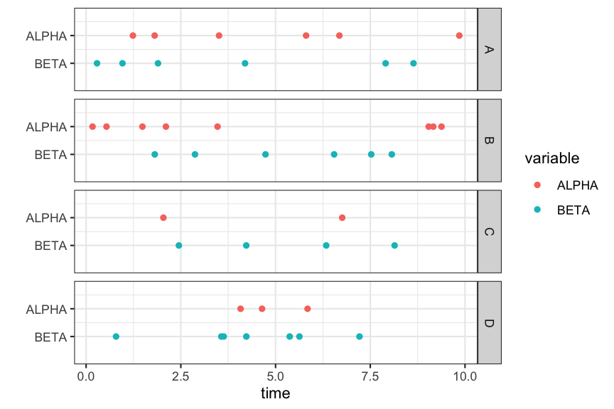

```r
plot(pointExam[, -(1:3)])
```

Or a slightly different version.

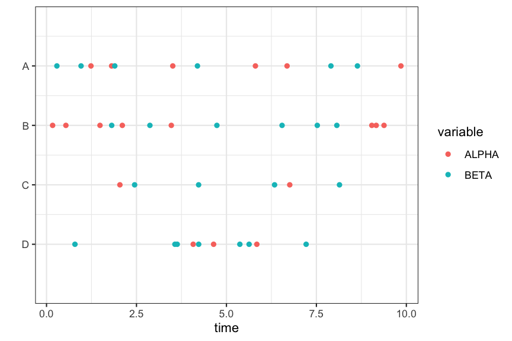

```r
plot(pointExam[, -(1:3)], y = "id") + facet_null()
```

Plotting the continuous process data only.

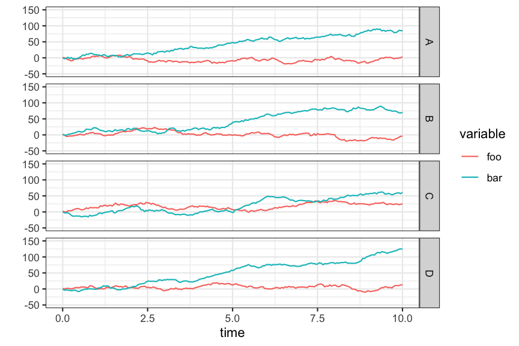

```r
plot(pointExam[, -c(4,5)])
```

or

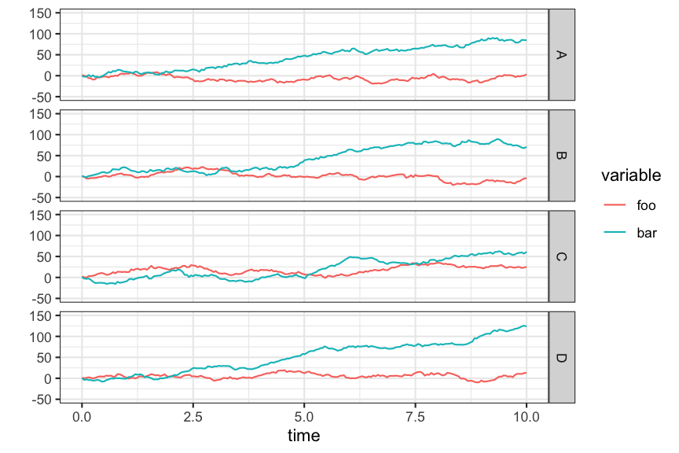

```r
plot(as(pointExam, "ContinuousProcess"))
```

Some modifications of the plot.

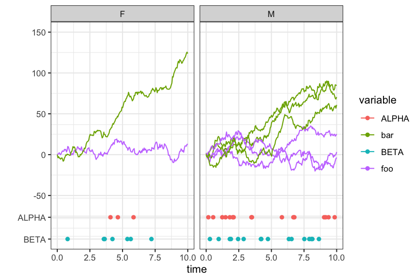

```r
plot(pointExam, allUnitData = TRUE) + facet_grid(.~gender)
```

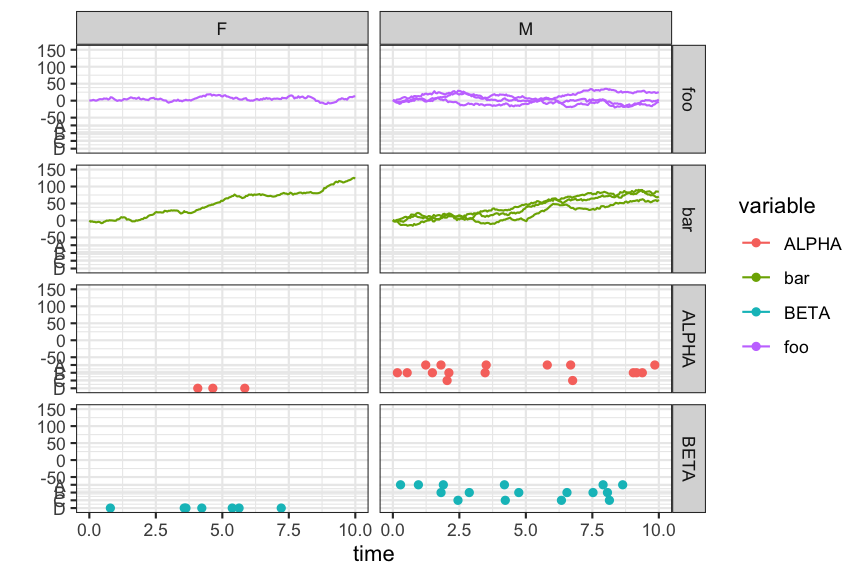

```r
plot(pointExam, y = "id", allUnitData = TRUE) + facet_grid(variable~gender, scale = "free_y")
```

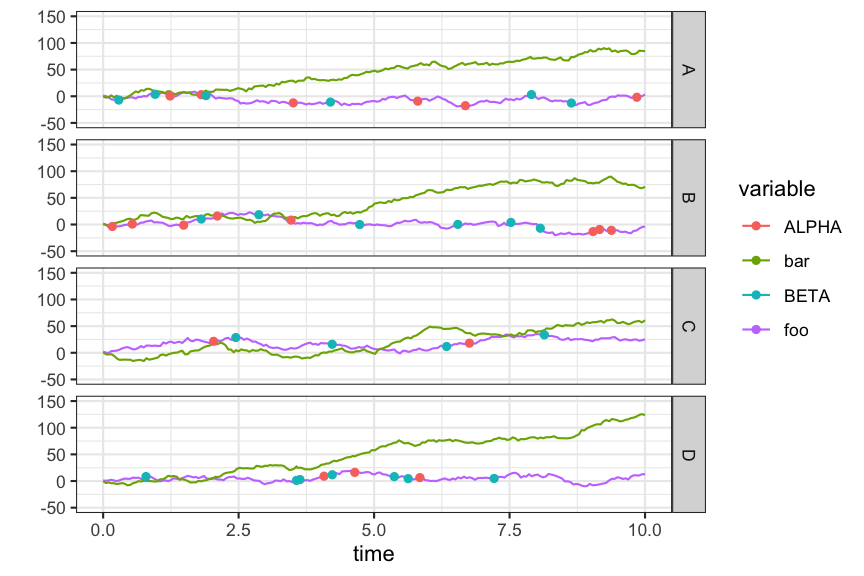

```r
plot(pointExam, y = "foo")
```

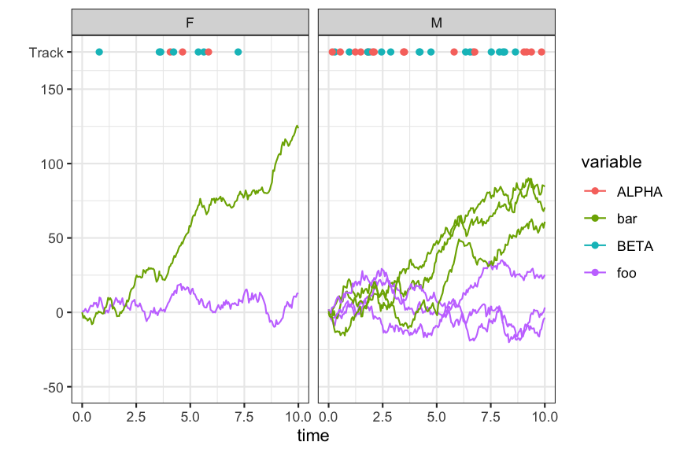

```r
plot(pointExam, y = "@top", allUnitData = TRUE) + facet_grid(.~gender)
```

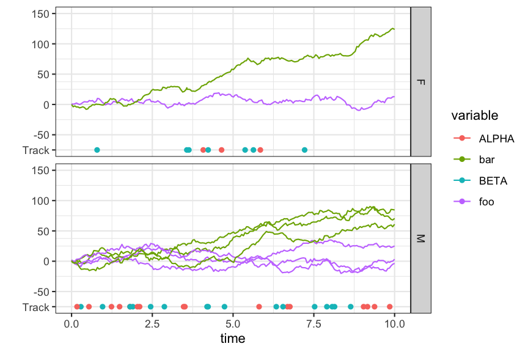

```r
plot(pointExam, y = "@bottom", allUnitData = TRUE) + facet_grid(gender~., scales = "free_y")
```

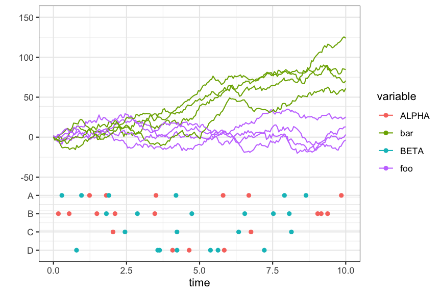

```r
plot(pointExam, y = "id") + facet_null()
```

A `JumpProcess` data set has points with the same marks as the variable names in the `ContinuousProcess` part of the data set. In addition, to each point there is a size of the jump associated.

```r
jumpExam
```

```
## Class: JumpProcess
## Dimensions: 4041 x 6
## Index variable: time
##
## 4 units.
##    id: A B C D
##
## 6 variables.
##    gender foo bar bar foo jump
```

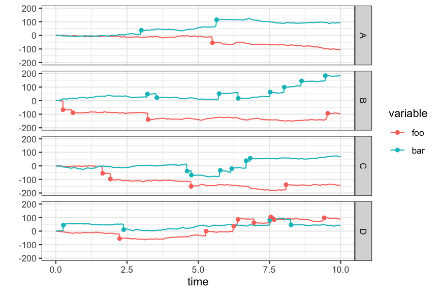

```r
plot(jumpExam)
```

We can again use ggplot2 for modifications

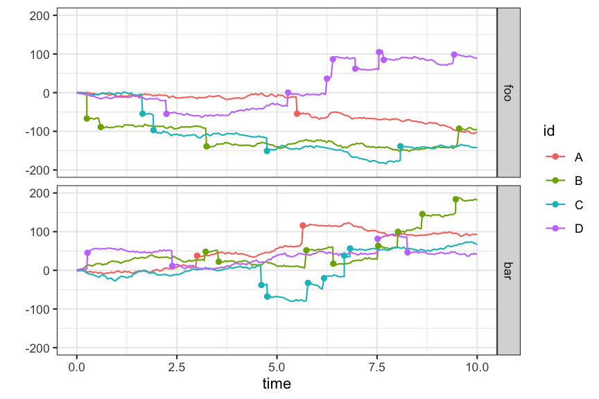

```r
plot(jumpExam) + facet_grid(variable ~ .) + aes(color = id)
```

Removing objects.

```r
rm(contExam)
rm(pointExam)
rm(jumpExam)
```